# R语言统计分析

## 6.4 多组独立样本非参数检验

### Kruskal-Wallis检验

**数学基础**：

检验多组独立样本是否来自同一分布（非参数方差分析）。

**检验统计量**：
$$H =
\frac{12}{N(N+1)}\sum\frac{R_i^2}{n_i} - 3(N+1)$$

```r
# Kruskal-Wallis检验示例
# 场景：比较三种治疗方法的疗效评分

set.seed(222222)
treatment_A <- rnorm(20, mean = 60, sd = 15)
treatment_B <- rnorm(20, mean = 70, sd = 15)
treatment_C <- rnorm(20, mean = 55, sd = 15)

# 创建数据框
kw_data <- data.frame(
  score = c(treatment_A, treatment_B, treatment_C),
  group = factor(rep(c("A", "B", "C"), each = 20))
)

# Kruskal-Wallis检验
kw_test <- kruskal.test(score ~ group, data = kw_data)
kw_test
```

```
##
##  Kruskal-Wallis rank sum test
##
## data:  score by group
## Kruskal-Wallis chi-squared = 15.181, df = 2, p-value = 0.0005051
```

```r
# 事后多重比较（Dunn检验）
# 使用pairwise.wilcox.test
pairwise.wilcox.test(kw_data$score, kw_data$group,
                      p.adjust.method = "bonferroni")
```

```
##
##  Pairwise comparisons using Wilcoxon rank sum exact test
##
## data:  kw_data$score and kw_data$group
##
##   A       B
## B 0.24293 -
## C 0.03958 0.00036
##
## P value adjustment method: bonferroni
```

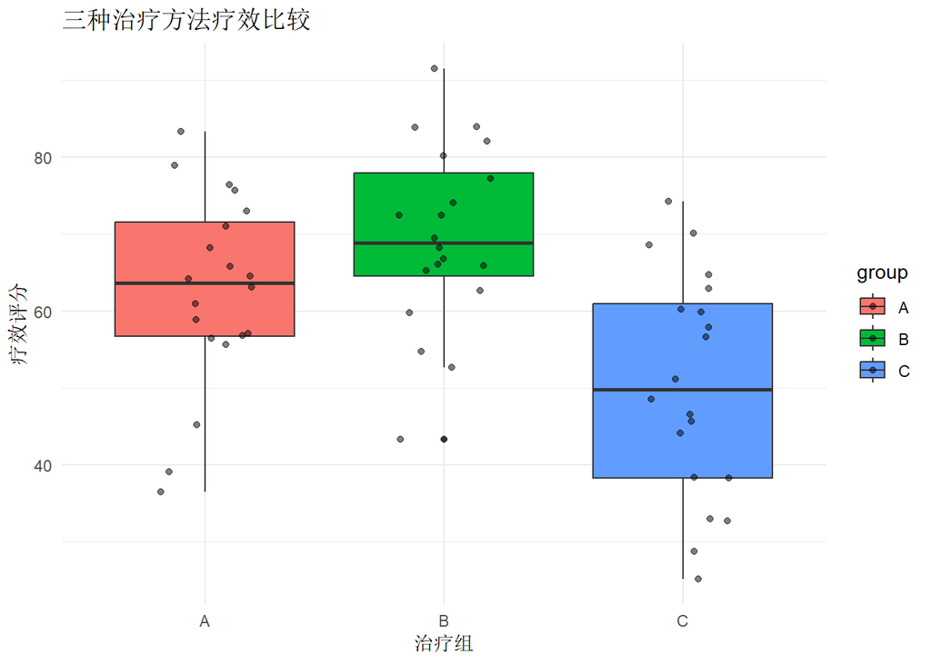

```r
# 可视化
ggplot2::ggplot(kw_data, ggplot2::aes(x = group, y = score, fill = group)) +
  ggplot2::geom_boxplot() +
  ggplot2::geom_jitter(width = 0.2, alpha = 0.5) +
  ggplot2::labs(title = "三种治疗方法疗效比较",
       x = "治疗组", y = "疗效评分") +
  ggplot2::theme_minimal()
```

## 6.5 多组相关样本非参数检验

### Friedman检验

**数学基础**：

检验多组相关样本（如重复测量）是否来自同一分布。

```r
# Friedman检验示例
# 场景：同一患者接受三种不同治疗的评分

set.seed(333333)
n_subjects <- 15

# 生成数据（每个受试者三种治疗）
treatment1 <- rnorm(n_subjects, mean = 60, sd = 10)
treatment2 <- treatment1 + rnorm(n_subjects, mean = 10, sd = 5)
treatment3 <- treatment1 + rnorm(n_subjects, mean = 5, sd = 8)

# 创建数据矩阵
friedman_matrix <- cbind(treatment1, treatment2, treatment3)

# Friedman检验
friedman_test <- friedman.test(friedman_matrix)
friedman_test
```

```
##
##  Friedman rank sum test
##
## data:  friedman_matrix
## Friedman chi-squared = 13.733, df = 2, p-value = 0.001042
```

```r
# 使用rstatix包（更现代的方法）
friedman_data <- data.frame(
  subject = factor(rep(1:n_subjects, 3)),
  treatment = factor(rep(c("T1", "T2", "T3"), each = n_subjects)),
  score = c(treatment1, treatment2, treatment3)
)

rstatix::friedman_test(friedman_data, score ~ treatment | subject)
```

```
## # A tibble: 1 × 6
##   .y.       n statistic    df       p method
## * <chr> <int>     <dbl> <dbl>   <dbl> <chr>
## 1 score    15      13.7     2 0.00104 Friedman test
```

```r
# 事后比较
pairwise.wilcox.test(friedman_data$score, friedman_data$treatment,
                      paired = TRUE, p.adjust.method = "bonferroni")
```

```
##
##  Pairwise comparisons using Wilcoxon signed rank exact test
##
## data:  friedman_data$score and friedman_data$treatment
##
##    T1      T2
## T2 0.00037 -
## T3 0.04523 0.36163
##
## P value adjustment method: bonferroni
```

## 6.6 分类变量关联性检验

### 6.6.1 卡方独立性检验

**数学基础**：

检验两个分类变量是否独立。

```r
# 卡方独立性检验示例
# 场景：检验吸烟与肺癌的关系

# 创建列联表
smoking_cancer <- matrix(c(60, 40, 30, 70), nrow = 2)
rownames(smoking_cancer) <- c("吸烟", "不吸烟")
colnames(smoking_cancer) <- c("肺癌", "无肺癌")
smoking_cancer
```

```
##        肺癌 无肺癌
## 吸烟     60     30
## 不吸烟   40     70
```

```r
# 卡方独立性检验
chisq_ind <- chisq.test(smoking_cancer)
chisq_ind
```

```
##
##  Pearson's Chi-squared test with Yates' continuity correction
##
## data:  smoking_cancer
## X-squared = 16.99, df = 1, p-value = 3.758e-05
```

```r
# 查看期望频数
chisq_ind$expected
```

```
##        肺癌 无肺癌
## 吸烟     45     45
## 不吸烟   55     55
```

```r
# 查看残差
chisq_ind$residuals
```

```
##             肺癌    无肺癌
## 吸烟    2.236068 -2.236068
## 不吸烟 -2.022600  2.022600
```

```r
# 效应量（Cramér's V）
vcd::assocstats(smoking_cancer)
```

```
##                     X^2 df   P(> X^2)
## Likelihood Ratio 18.480  1 1.7167e-05
## Pearson          18.182  1 2.0079e-05
##
## Phi-Coefficient   : 0.302
## Contingency Coeff.: 0.289
## Cramer's V        : 0.302
```

### 6.6.2 Fisher精确检验

**数学基础**：

适用于小样本或期望频数较小的情况。

```r
# Fisher精确检验示例
# 场景：小样本的药物治疗效果

# 创建2x2列联表
treatment_outcome <- matrix(c(8, 2, 3, 7), nrow = 2)
rownames(treatment_outcome) <- c("治疗组", "对照组")
colnames(treatment_outcome) <- c("有效", "无效")
treatment_outcome
```

```
##        有效 无效
## 治疗组    8    3
## 对照组    2    7
```

```r
# Fisher精确检验
fisher_test <- fisher.test(treatment_outcome)
fisher_test
```

```
##
##  Fisher's Exact Test for Count Data
##
## data:  treatment_outcome
## p-value = 0.06978
## alternative hypothesis: true odds ratio is not equal to 1
## 95 percent confidence interval:
##    0.8821175 127.0558418
## sample estimates:
## odds ratio
##   8.153063
```

```r
# 单侧检验
fisher.test(treatment_outcome, alternative = "greater")
```

```
##
##  Fisher's Exact Test for Count Data
##
## data:  treatment_outcome
## p-value = 0.03489
## alternative hypothesis: true odds ratio is greater than 1
## 95 percent confidence interval:
##  1.155327      Inf
## sample estimates:
## odds ratio
##   8.153063
```

```r
# 使用exact2x2包进行更精确的计算
exact2x2::exact2x2(treatment_outcome)
```

```
##
##  Two-sided Fisher's Exact Test (usual method using minimum likelihood)
##
## data:  treatment_outcome
## p-value = 0.06978
## alternative hypothesis: true odds ratio is not equal to 1
## 95 percent confidence interval:
##   1.0000 84.0382
## sample estimates:
## odds ratio
##   8.153063
```

## 6.7 一致性检验

### McNemar检验

**数学基础**：

检验配对分类变量的变化是否显著。

```r
# McNemar检验示例
# 场景：治疗前后症状的变化

# 创建配对列联表
# 行：治疗前（有症状/无症状）
# 列：治疗后（有症状/无症状）
mcnemar_table <- matrix(c(20, 30, 10, 40), nrow = 2)
rownames(mcnemar_table) <- c("治疗前有症状", "治疗前无症状")
colnames(mcnemar_table) <- c("治疗后有症状", "治疗后无症状")
mcnemar_table
```

```
##              治疗后有症状 治疗后无症状
## 治疗前有症状           20           10
## 治疗前无症状           30           40
```

```r
# McNemar检验
mcnemar_test <- mcnemar.test(mcnemar_table)
mcnemar_test
```

```
##
##  McNemar's Chi-squared test with continuity correction
##
## data:  mcnemar_table
## McNemar's chi-squared = 9.025, df = 1, p-value = 0.002663
```

```r
# 精确McNemar检验（小样本）
# 使用exact2x2包
exact2x2::mcnemar.exact(mcnemar_table)
```

```
##
##  Exact McNemar test (with central confidence intervals)
##
## data:  mcnemar_table
## b = 10, c = 30, p-value = 0.002221
## alternative hypothesis: true odds ratio is not equal to 1
## 95 percent confidence interval:
##  0.1453636 0.7005703
## sample estimates:
## odds ratio
##  0.3333333
```

## 6.8 游程检验（随机性检验）

**数学基础**：

检验数据是否随机分布。

```r
# 游程检验示例
set.seed(444444)

# 生成随机序列
random_seq <- sample(c(0, 1), 50, replace = TRUE)

# 生成有趋势的序列
trend_seq <- c(rep(0, 25), rep(1, 25))

# 使用DescTools包的RunsTest
DescTools::RunsTest(random_seq)
```

```
##
##  Runs Test for Randomness
##
## data:  random_seq
## z = -0.9904, runs = 22, m = 26, n = 24, p-value = 0.322
## alternative hypothesis: true number of runs is not equal the expected number
```

```r
DescTools::RunsTest(trend_seq)
```

```
##
##  Runs Test for Randomness
##
## data:  trend_seq
## z = -6.7157, runs = 2, m = 25, n = 25, p-value = 1.872e-11
## alternative hypothesis: true number of runs is not equal the expected number
```

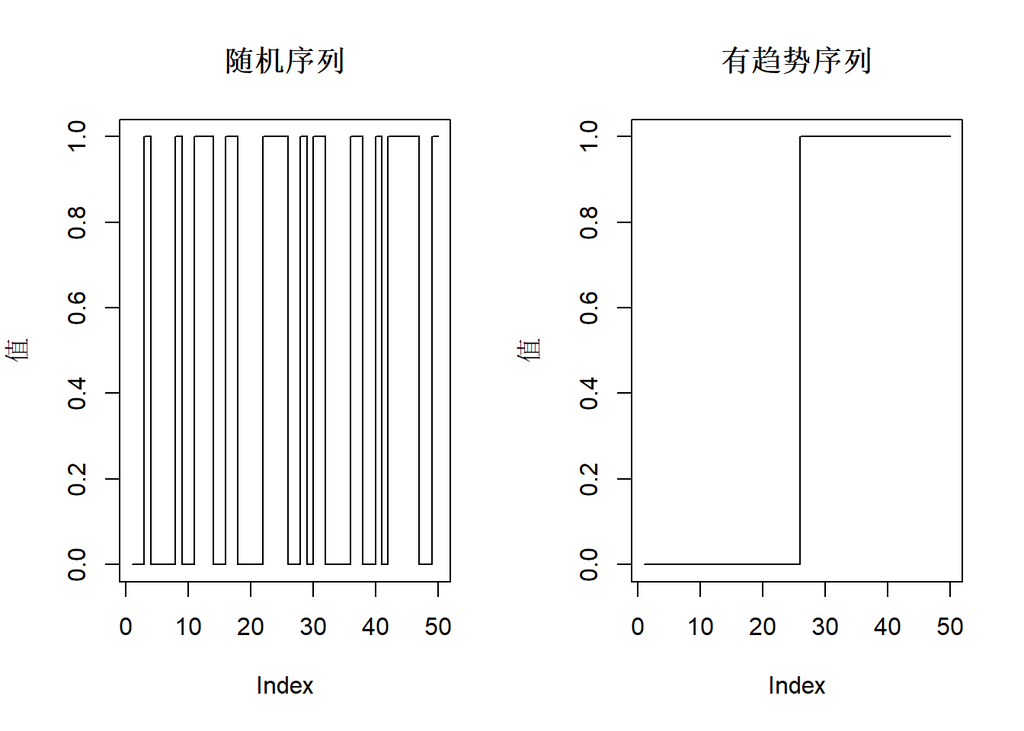

```r
# 可视化
par(mfrow = c(1, 2))
plot(random_seq, type = "s", main = "随机序列", ylab = "值")
plot(trend_seq, type = "s", main = "有趋势序列", ylab = "值")
```

```r
par(mfrow = c(1, 1))
```

## 6.9 相关性非参数检验

### Spearman秩相关与Kendall’s tau

```r
# 非参数相关检验示例
set.seed(555555)
x <- rnorm(30, mean = 50, sd = 10)
y <- x + rnorm(30, mean = 0, sd = 15)

# Spearman秩相关
spearman_cor <- cor.test(x, y, method = "spearman")
spearman_cor
```

```
##
##  Spearman's rank correlation rho
##
## data:  x and y
## S = 1968, p-value = 0.001468
## alternative hypothesis: true rho is not equal to 0
## sample estimates:
##       rho
## 0.5621802
```

```r
# Kendall's tau
kendall_cor <- cor.test(x, y, method = "kendall")
kendall_cor
```

```
##
##  Kendall's rank correlation tau
##
## data:  x and y
## T = 302, p-value = 0.002238
## alternative hypothesis: true tau is not equal to 0
## sample estimates:
##       tau
## 0.3885057
```

```r
# 与Pearson相关比较
pearson_cor <- cor.test(x, y, method = "pearson")

cat("Pearson相关系数:", pearson_cor$estimate, "p值:", pearson_cor$p.value, "\n")
```

```
## Pearson相关系数: 0.6425019 p值: 0.0001290706
```

```r
cat("Spearman相关系数:", spearman_cor$estimate, "p值:", spearman_cor$p.value, "\n")
```

```
## Spearman相关系数: 0.5621802 p值: 0.001467922
```

```r
cat("Kendall's tau:", kendall_cor$estimate, "p值:", kendall_cor$p.value, "\n")
```

```
## Kendall's tau: 0.3885057 p值: 0.0022378
```

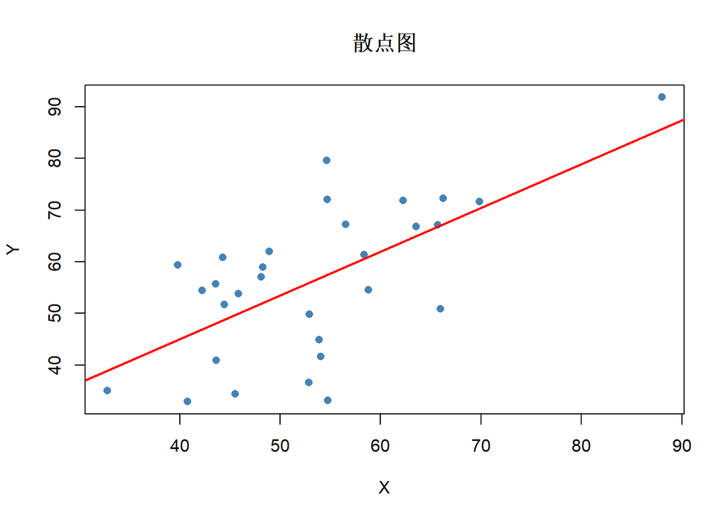

```r
# 可视化
plot(x, y, main = "散点图", xlab = "X", ylab = "Y", pch = 16, col = "steelblue")
abline(lm(y ~ x), col = "red", lwd = 2)
```

## 第六章小结

| 检验类型 | 适用场景 | R函数 | 参数检验对应 |
| --- | --- | --- | --- |
| K-S检验 | 分布拟合检验 | ks.test() | - |
| 卡方拟合优度 | 频数分布检验 | chisq.test() | - |
| Mann-Whitney U | 两独立样本比较 | wilcox.test() | 独立样本t检验 |
| Wilcoxon符号秩 | 两配对样本比较 | wilcox.test(paired=TRUE) | 配对t检验 |
| Kruskal-Wallis | 多组独立样本 | kruskal.test() | 单因素ANOVA |
| Friedman | 多组相关样本 | friedman.test() | 重复测量ANOVA |
| 卡方独立性 | 分类变量关联 | chisq.test() | - |
| Fisher精确检验 | 小样本列联表 | fisher.test() | - |
| McNemar检验 | 配对分类变量 | mcnemar.test() | - |
| Spearman相关 | 等级相关 | cor.test(method=“spearman”) | Pearson相关 |

# 第七章：方差分析（ANOVA）

方差分析是用于比较多组均值差异的统计方法，是t检验的扩展。本章将介绍各种方差分析方法及其在R中的实现。

**方差分析的基本思想**：

将总变异分解为组间变异和组内变异，通过比较两者的大小来判断组间均值是否有显著差异。

## 7.1 方差分析的基本思想

### 数学基础

**总变异分解**：
$$SS_{total}
= SS_{between} + SS_{within}$$

**F统计量**：
$$F =
\frac{MS_{between}}{MS_{within}} =
\frac{SS_{between}/(k-1)}{SS_{within}/(N-k)}$$

其中： - $SS_{between}$：组间平方和 - $SS_{within}$：组内平方和 - k：组数 - N：总样本量

**假设条件**： 1. 各组数据来自正态分布 2. 各组方差相等（方差齐性） 3. 观测值独立

```r
# 方差分析基本概念演示
set.seed(666666)

# 生成三组数据
group1 <- rnorm(20, mean = 50, sd = 10)
group2 <- rnorm(20, mean = 55, sd = 10)
group3 <- rnorm(20, mean = 60, sd = 10)

# 创建数据框
anova_data <- data.frame(
  value = c(group1, group2, group3),
  group = factor(rep(c("A", "B", "C"), each = 20))
)

# 计算各部分变异
grand_mean <- mean(anova_data$value)
group_means <- tapply(anova_data$value, anova_data$group, mean)

# 总平方和
SS_total <- sum((anova_data$value - grand_mean)^2)

# 组间平方和
SS_between <- sum(20 * (group_means - grand_mean)^2)

# 组内平方和
SS_within <- sum(sapply(1:3, function(i) {
  sum((anova_data$value[anova_data$group == unique(anova_data$group)[i]] -
       group_means[i])^2)
}))

# 均方
MS_between <- SS_between / 2  # df = k-1 = 2
MS_within <- SS_within / 57   # df = N-k = 57

# F统计量
F_stat <- MS_between / MS_within

cat("总平方和 SS_total:", SS_total, "\n")
```

```
## 总平方和 SS_total: 6434.028
```

```r
cat("组间平方和 SS_between:", SS_between, "\n")
```

```
## 组间平方和 SS_between: 1673.201
```

```r
cat("组内平方和 SS_within:", SS_within, "\n")
```

```
## 组内平方和 SS_within: 4760.827
```

```r
cat("验证: SS_between + SS_within =", SS_between + SS_within, "\n")
```

```
## 验证: SS_between + SS_within = 6434.028
```

```r
cat("F统计量:", F_stat, "\n")
```

```
## F统计量: 10.01638
```

```r
# p值
p_value <- 1 - pf(F_stat, 2, 57)
cat("p值:", p_value, "\n")
```

```
## p值: 0.0001871473
```

## 7.2 单因素方差分析

### 数学基础

检验一个因素的多个水平之间均值是否有显著差异。

**假设**： - H₀: $\mu_1 = \mu_2 = ... = \mu_k$ - H₁: 至少有两个均值不相等

```r
# 单因素方差分析示例
# 场景：比较三种药物的降压效果

set.seed(777777)
drug_A <- rnorm(25, mean = 10, sd = 3)
drug_B <- rnorm(25, mean = 12, sd = 3)
drug_C <- rnorm(25, mean = 8, sd = 3)

drug_data <- data.frame(
  reduction = c(drug_A, drug_B, drug_C),
  drug = factor(rep(c("A", "B", "C"), each = 25))
)

# 描述性统计
drug_data %>%
  dplyr::group_by(drug) %>%
  dplyr::summarise(
    n = dplyr::n(),
    mean = mean(reduction),
    sd = sd(reduction)
  )
```

```
## # A tibble: 3 × 4
##   drug      n  mean    sd
##   <fct> <int> <dbl> <dbl>
## 1 A        25  9.27  2.84
## 2 B        25 12.1   3.88
## 3 C        25  9.02  2.65
```

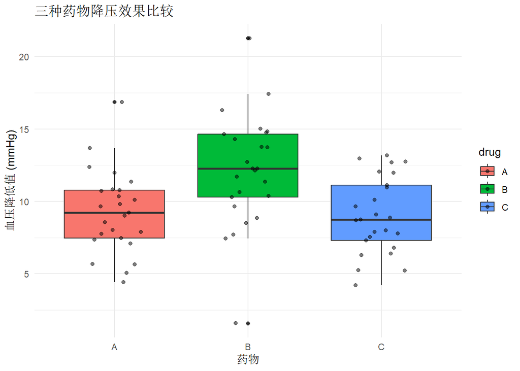

```r
# 可视化
ggplot2::ggplot(drug_data, ggplot2::aes(x = drug, y = reduction, fill = drug)) +
  ggplot2::geom_boxplot() +
  ggplot2::geom_jitter(width = 0.2, alpha = 0.5) +
  ggplot2::labs(title = "三种药物降压效果比较",
       x = "药物", y = "血压降低值 (mmHg)") +
  ggplot2::theme_minimal()
```

```r
# 单因素ANOVA
anova_result <- aov(reduction ~ drug, data = drug_data)
summary(anova_result)
```

```
##             Df Sum Sq Mean Sq F value  Pr(>F)
## drug         2  150.6   75.29   7.506 0.00109 **
## Residuals   72  722.1   10.03
## ---
## Signif. codes:  0 '***' 0.001 '**' 0.01 '*' 0.05 '.' 0.1 ' ' 1
```

```r
# 使用rstatix包（更现代的方法）
rstatix::anova_test(drug_data, reduction ~ drug)
```

```
## ANOVA Table (type II tests)
##
##   Effect DFn DFd     F     p p<.05   ges
## 1   drug   2  72 7.506 0.001     * 0.173
```

## 7.3 事后检验

当ANOVA结果显著时，需要进行事后检验确定哪些组之间存在差异。

### 常用方法

| 方法 | 特点 | 适用场景 |
| --- | --- | --- |
| Tukey HSD | 最常用，控制整体错误率 | 各组样本量相等 |
| Bonferroni | 保守，简单 | 任意样本量 |
| Dunnett | 与对照组比较 | 有对照组的设计 |
| Games-Howell | 不要求方差齐性 | 方差不齐时 |

```r
# 事后检验示例

# Tukey HSD检验
tukey_result <- TukeyHSD(anova_result)
tukey_result
```

```
##   Tukey multiple comparisons of means
##     95% family-wise confidence level
##
## Fit: aov(formula = reduction ~ drug, data = drug_data)
##
## $drug
##           diff        lwr        upr     p adj
## B-A  2.8760696  0.7324225  5.0197167 0.0055523
## C-A -0.2443531 -2.3880001  1.8992940 0.9598319
## C-B -3.1204227 -5.2640697 -0.9767756 0.0024103
```

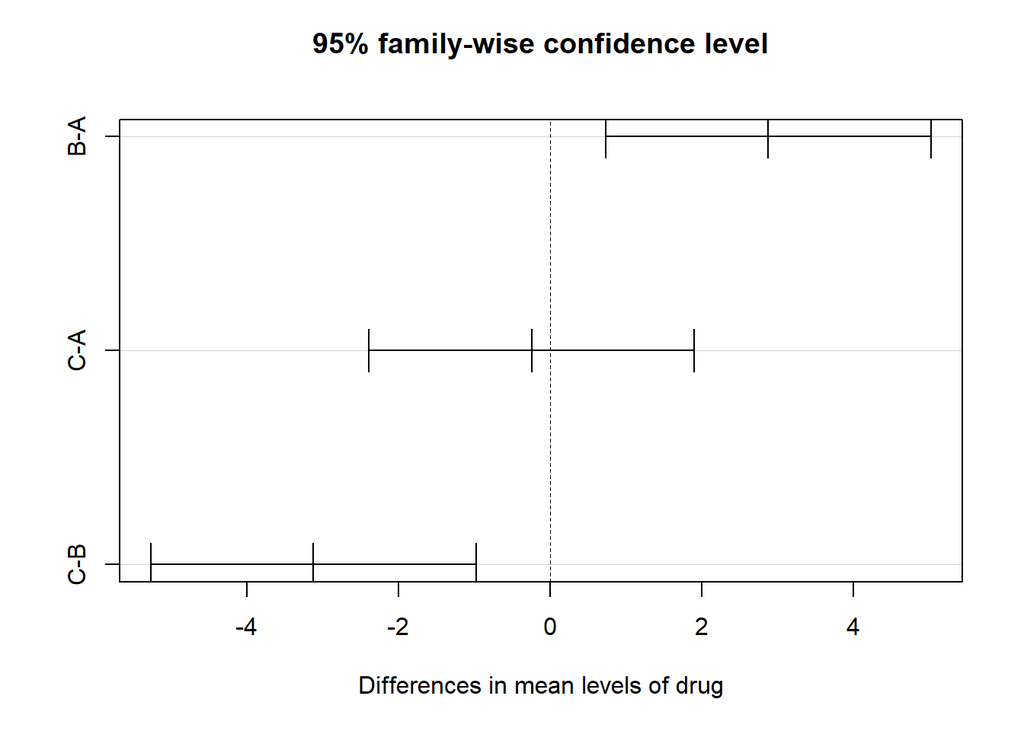

```r
# 可视化Tukey结果
plot(tukey_result)
```

```r
# 使用multcomp包
library(multcomp)
tukey_mc <- glht(anova_result, linfct = mcp(drug = "Tukey"))
summary(tukey_mc)
```

```
##
##   Simultaneous Tests for General Linear Hypotheses
##
## Multiple Comparisons of Means: Tukey Contrasts
##
##
## Fit: aov(formula = reduction ~ drug, data = drug_data)
##
## Linear Hypotheses:
##            Estimate Std. Error t value Pr(>|t|)
## B - A == 0   2.8761     0.8958   3.211  0.00551 **
## C - A == 0  -0.2444     0.8958  -0.273  0.95983
## C - B == 0  -3.1204     0.8958  -3.484  0.00243 **
## ---
## Signif. codes:  0 '***' 0.001 '**' 0.01 '*' 0.05 '.' 0.1 ' ' 1
## (Adjusted p values reported -- single-step method)
```

```r
# Dunnett检验（与对照比较，假设A为对照组）
dunnett_mc <- glht(anova_result, linfct = mcp(drug = "Dunnett"))
summary(dunnett_mc)
```

```
##
##   Simultaneous Tests for General Linear Hypotheses
##
## Multiple Comparisons of Means: Dunnett Contrasts
##
##
## Fit: aov(formula = reduction ~ drug, data = drug_data)
##
## Linear Hypotheses:
##            Estimate Std. Error t value Pr(>|t|)
## B - A == 0   2.8761     0.8958   3.211  0.00383 **
## C - A == 0  -0.2444     0.8958  -0.273  0.94710
## ---
## Signif. codes:  0 '***' 0.001 '**' 0.01 '*' 0.05 '.' 0.1 ' ' 1
## (Adjusted p values reported -- single-step method)
```

```r
# Bonferroni校正的成对t检验
pairwise.t.test(drug_data$reduction, drug_data$drug,
                p.adjust.method = "bonferroni")
```

```
##
##  Pairwise comparisons using t tests with pooled SD
##
## data:  drug_data$reduction and drug_data$drug
##
##   A      B
## B 0.0059 -
## C 1.0000 0.0025
##
## P value adjustment method: bonferroni
```

```r
# Games-Howell检验（方差不齐时）
rstatix::games_howell_test(drug_data, reduction ~ drug)
```

```
## # A tibble: 3 × 8
##   .y.       group1 group2 estimate conf.low conf.high p.adj p.adj.signif
## * <chr>     <chr>  <chr>     <dbl>    <dbl>     <dbl> <dbl> <chr>
## 1 reduction A      B         2.88     0.546     5.21  0.012 *
## 2 reduction A      C        -0.244   -2.12      1.63  0.947 ns
## 3 reduction B      C        -3.12    -5.40     -0.840 0.005 **
```

## 7.4 多因素方差分析

### 数学基础

检验多个因素及其交互作用对结果的影响。

```r
# 多因素方差分析示例
# 场景：研究药物类型和剂量对血压的影响

set.seed(888888)

# 2x3设计：2种药物 x 3种剂量
n_per_group <- 10

factorial_data <- data.frame(
  drug = factor(rep(rep(c("A", "B"), each = 3), each = n_per_group)),
  dose = factor(rep(rep(c("Low", "Medium", "High"), 2), each = n_per_group)),
  reduction = c(
    rnorm(n_per_group, 5, 2),   # A, Low
    rnorm(n_per_group, 8, 2),   # A, Medium
    rnorm(n_per_group, 10, 2),  # A, High
    rnorm(n_per_group, 6, 2),   # B, Low
    rnorm(n_per_group, 12, 2),  # B, Medium
    rnorm(n_per_group, 15, 2)   # B, High
  )
)

# 描述性统计
factorial_data %>%
  dplyr::group_by(drug, dose) %>%
  dplyr::summarise(
    n = dplyr::n(),
    mean = mean(reduction),
    sd = sd(reduction)
  )
```

[output not shown]

```
## # A tibble: 6 × 5
## # Groups:   drug [2]
##   drug  dose       n  mean    sd
##   <fct> <fct>  <int> <dbl> <dbl>
## 1 A     High      10  9.88 0.858
## 2 A     Low       10  5.42 1.46
## 3 A     Medium    10  6.53 1.30
## 4 B     High      10 14.5  1.71
## 5 B     Low       10  5.81 1.55
## 6 B     Medium    10 12.2  1.67
```

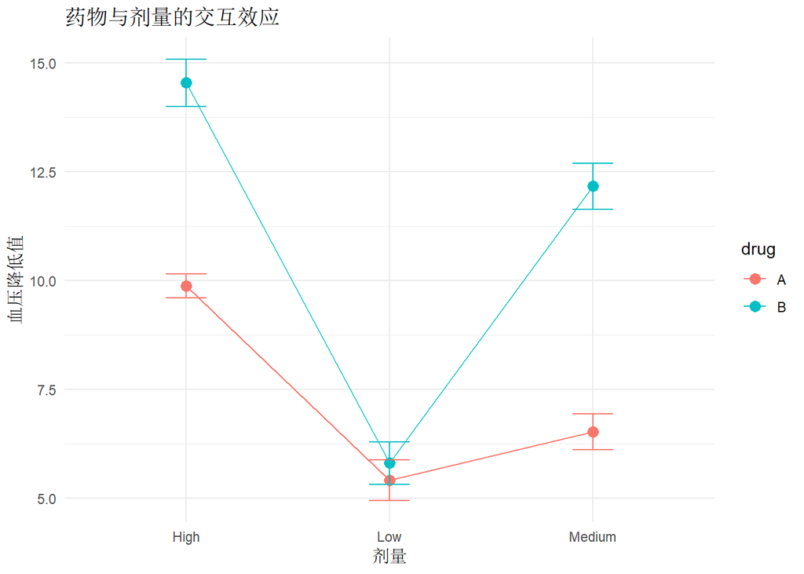

```r
# 可视化交互效应
ggplot2::ggplot(factorial_data, ggplot2::aes(x = dose, y = reduction,
                                       color = drug, group = drug)) +
  ggplot2::stat_summary(fun = mean, geom = "point", size = 3) +
  ggplot2::stat_summary(fun = mean, geom = "line") +
  ggplot2::stat_summary(fun.data = mean_se, geom = "errorbar", width = 0.2) +
  ggplot2::labs(title = "药物与剂量的交互效应",
       x = "剂量", y = "血压降低值") +
  ggplot2::theme_minimal()
```

```r
# 两因素ANOVA
factorial_anova <- aov(reduction ~ drug * dose, data = factorial_data)
summary(factorial_anova)
```

```
##             Df Sum Sq Mean Sq F value   Pr(>F)
## drug         1  191.0  191.03    90.5 3.88e-13 ***
## dose         2  438.1  219.03   103.8  < 2e-16 ***
## drug:dose    2   78.1   39.05    18.5 7.59e-07 ***
## Residuals   54  114.0    2.11
## ---
## Signif. codes:  0 '***' 0.001 '**' 0.01 '*' 0.05 '.' 0.1 ' ' 1
```

```r
# 使用rstatix
rstatix::anova_test(factorial_data, reduction ~ drug * dose)
```

```
## ANOVA Table (type II tests)
##
##      Effect DFn DFd       F        p p<.05   ges
## 1      drug   1  54  90.499 3.88e-13     * 0.626
## 2      dose   2  54 103.764 3.17e-19     * 0.794
## 3 drug:dose   2  54  18.502 7.59e-07     * 0.407
```

## 7.5 重复测量方差分析

### 数学基础

同一受试者在不同时间点或条件下的多次测量。

```r
# 重复测量方差分析示例
# 场景：患者治疗前、中、后的血压变化

set.seed(999999)
n_subjects <- 20

# 生成重复测量数据
baseline <- rnorm(n_subjects, mean = 140, sd = 10)
midterm <- baseline - rnorm(n_subjects, mean = 5, sd = 5)
final <- baseline - rnorm(n_subjects, mean = 10, sd = 6)

rm_data <- data.frame(
  subject = factor(rep(1:n_subjects, 3)),
  time = factor(rep(c("Baseline", "Midterm", "Final"), each = n_subjects),
                levels = c("Baseline", "Midterm", "Final")),
  bp = c(baseline, midterm, final)
)

# 描述性统计
rm_data %>%
  dplyr::group_by(time) %>%
  dplyr::summarise(
    n = dplyr::n(),
    mean = mean(bp),
    sd = sd(bp)
  )
```

```
## # A tibble: 3 × 4
##   time         n  mean    sd
##   <fct>    <int> <dbl> <dbl>
## 1 Baseline    20  135.  10.2
## 2 Midterm     20  131.  11.7
## 3 Final       20  125.  13.2
```

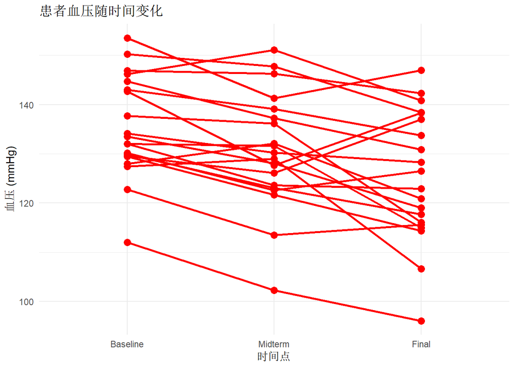

```r
# 可视化
ggplot2::ggplot(rm_data, ggplot2::aes(x = time, y = bp, group = subject)) +
  ggplot2::geom_line(alpha = 0.3) +
  ggplot2::geom_point(alpha = 0.5) +
  ggplot2::stat_summary(fun = mean, geom = "point", size = 3, color = "red") +
  ggplot2::stat_summary(fun = mean, geom = "line", color = "red", size = 1) +
  ggplot2::labs(title = "患者血压随时间变化",
       x = "时间点", y = "血压 (mmHg)") +
  ggplot2::theme_minimal()
```

```r
# 使用rstatix进行重复测量ANOVA
rstatix::anova_test(rm_data, bp ~ time, within = subject)
```

```
## ANOVA Table (type II tests)
##
##   Effect DFn DFd     F     p p<.05   ges
## 1   time   2  57 3.564 0.035     * 0.111
```

```r
# 使用afex包
afex::aov_ez(data = rm_data, dv = "bp", within = "time", id = "subject")
```

```
## Anova Table (Type 3 tests)
##
## Response: bp
##   Effect          df   MSE         F  ges p.value
## 1   time 1.45, 27.59 35.61 19.15 *** .111   <.001
## ---
## Signif. codes:  0 '***' 0.001 '**' 0.01 '*' 0.05 '+' 0.1 ' ' 1
##
## Sphericity correction method: GG
```

```r
# 事后检验
rstatix::pairwise_t_test(rm_data, bp ~ time, paired = TRUE,
                         p.adjust.method = "bonferroni")
```

```
## # A tibble: 3 × 10
##   .y.   group1   group2    n1    n2 statistic    df       p   p.adj p.adj.signif
## * <chr> <chr>    <chr>  <int> <int>     <dbl> <dbl>   <dbl>   <dbl> <chr>
## 1 bp    Baseline Midte…    20    20      4.10    19 6.11e-4 2   e-3 **
## 2 bp    Baseline Final     20    20      6.53    19 2.95e-6 8.85e-6 ****
## 3 bp    Midterm  Final     20    20      2.56    19 1.9 e-2 5.8 e-2 ns
```